# College Dataset

### Scatter plot

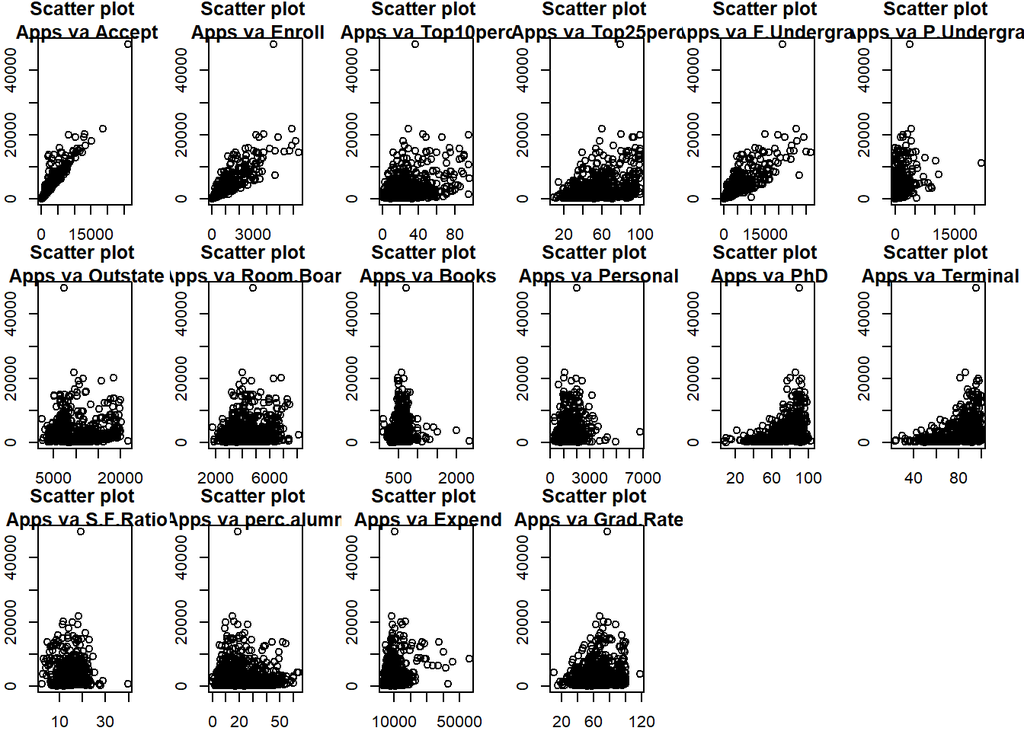

```r
par(mfrow=c(3,6),mar=c(2,2,2,2))
for (i in 3:18){
  plot(data_2[,i],data_2$Apps,
       main=paste("Scatter plot \n Apps va",names(data_2)[i]),
       xlab = "")
}
par(mfrow=c(1,1),mar=c(5,4,4,2)+0.1)
```

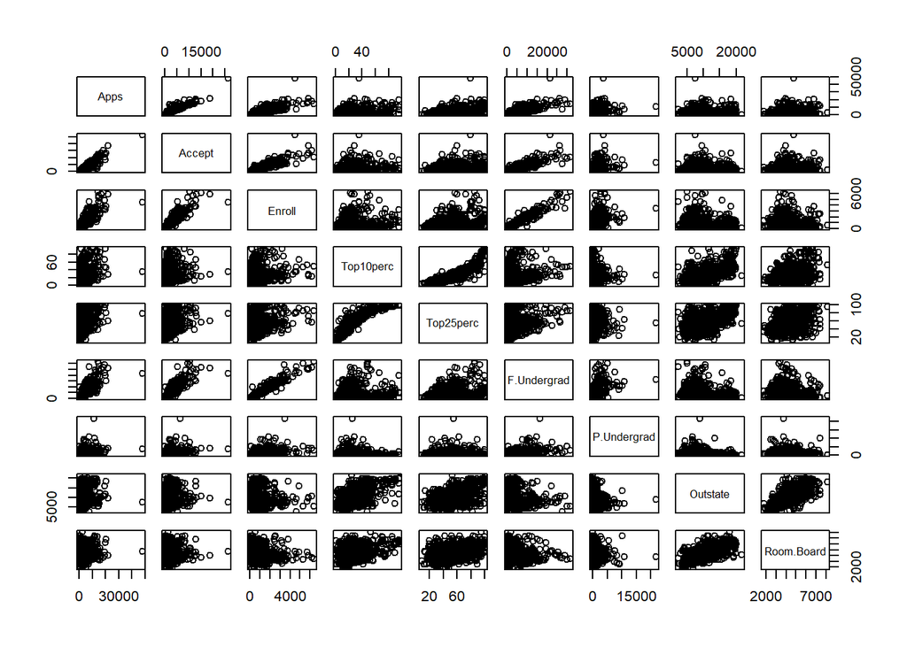

```r
#we can also use pairs to see the relationship between variables,
pairs(data_2[,2:10])
```

According to the scatter plots it seems that Apps has some degree of linear relationship with Accept, Enroll, F-Undergrad.

### Correlation Analysis

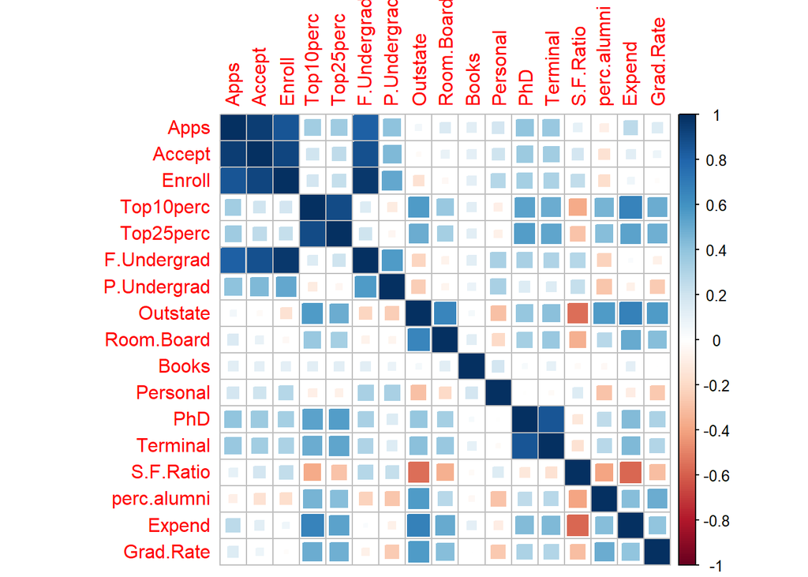

```r
cor_tab<-round(cor(data_2[,2:18]),2)
corrplot::corrplot(cor_tab,method="square",)
```

According to the graph there is strong correlation between:

- Apps, Accept, Enroll, F.Undergrad.
- Top10perc and Top25perc, Expend
- Outstate and Room.board, perc.alumni, Expend, Grad.Rate
- P.hD and Terminal
- S.F.Ratio, Expend

**Note**: Strong correlation might lead to the multicolinearity problem in our model and we need to be cautious.

The correlation coefficient for first row is:

- Apps~Accept: 0.943.
- Apps~Enroll: 0.847.
- Apps~F.Undergrad: 0.814.

### Outlier detection

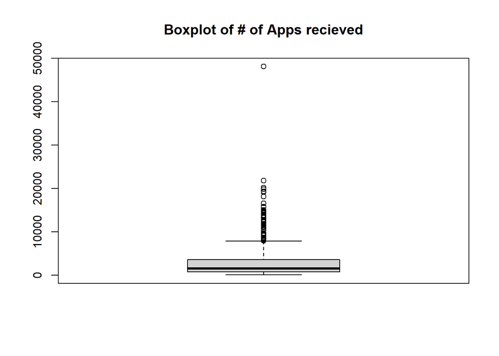

```r
#Identifying outliers
boxplot(data_2$Apps,main="Boxplot of # of Apps recieved")
```

```r
tukey_ul<-quantile(data_2$Apps,probs = 0.75)+1.5*IQR(data_2$Apps)
```

About 9.01 percent of the total data in Apps are outliers. However, after bulling model, the influential outliers on response variables could be defined based on cook’s distance.

## Part3: Modeling

### B- Divide Dataset into Train and Test

```r
#Feature Scaling
data_3<-data_2
data_3[,-1]<-apply(data_3[,-1],2,scale)
head(data_3,2)
```

```
##                              Private       Apps      Accept      Enroll
## Abilene Christian University     Yes -0.3466585 -0.32099869 -0.06346802
## Adelphi University               Yes -0.2107483 -0.03867808 -0.28839845
##                               Top10perc  Top25perc F.Undergrad P.Undergrad
## Abilene Christian University -0.2584163 -0.1917039  -0.1680076  -0.2090725
## Adelphi University           -0.6552335 -1.3530399  -0.2096534   0.2441498
##                                Outstate Room.Board      Books  Personal
## Abilene Christian University -0.7458755 -0.9642836 -0.6019244 1.2692276
## Adelphi University            0.4572019  1.9079789  1.2150971 0.2353633
##                                    PhD   Terminal S.F.Ratio perc.alumni
## Abilene Christian University -0.162923 -0.1156542  1.013123  -0.8670157
## Adelphi University           -2.673923 -3.3760014 -0.477397  -0.5442217
##                                  Expend  Grad.Rate
## Abilene Christian University -0.5015870 -0.3180471
## Adelphi University            0.1660029 -0.5509070
```

Since the order of variables are not the same, scaling the data (Standardization) will improve the models performance. As we are not going to predict the actual value for a specific university, the response variable is also scaled.

**Note: Removing influential outliers**

The model was run several times and it was found that based on cook distance and regression model, observation 484-Rutgers at New Brunswick and 462-Purdue University at West Lafayette is better to remove.There are outliers which have higher impact on regression multipliers.

```r
data_3<-data_3[-which(rownames(data_3) %in% c("Rutgers at New Brunswick", "Purdue University at West Lafayette")),]
set.seed(1234)
train_cases<-sample(1:nrow(data_3),0.7*nrow(data_3))
train<-data_3[train_cases,]
test<-data_3[-train_cases,]
```

Train Dimension: 542, 18.

Test Dimension: 233, 18.

### C: Linear Regression

```r
lm_1<-lm(Apps~.,data=train)
summary(lm_1)
```

```
##
## Call:
## lm(formula = Apps ~ ., data = train)
##
## Residuals:
##      Min       1Q   Median       3Q      Max
## -0.75736 -0.11393 -0.01457  0.08586  1.81179
##
## Coefficients:
##              Estimate Std. Error t value Pr(>|t|)
## (Intercept)  0.103419   0.031855   3.247  0.00124 **
## PrivateYes  -0.146646   0.040914  -3.584  0.00037 ***
## Accept       0.834584   0.039524  21.116  < 2e-16 ***
## Enroll      -0.137301   0.056052  -2.450  0.01463 *
## Top10perc    0.220948   0.029321   7.536 2.15e-13 ***
## Top25perc   -0.069238   0.026865  -2.577  0.01023 *
## F.Undergrad  0.137359   0.045950   2.989  0.00293 **
## P.Undergrad  0.026555   0.013514   1.965  0.04995 *
## Outstate    -0.044046   0.023910  -1.842  0.06601 .
## Room.Board   0.046667   0.015392   3.032  0.00255 **
## Books       -0.005321   0.010694  -0.498  0.61900
## Personal     0.001037   0.013830   0.075  0.94026
## PhD         -0.043847   0.022191  -1.976  0.04870 *
## Terminal    -0.008245   0.022231  -0.371  0.71087
## S.F.Ratio    0.024258   0.015599   1.555  0.12053
## perc.alumni -0.021759   0.015288  -1.423  0.15525
## Expend       0.098490   0.019228   5.122 4.25e-07 ***
## Grad.Rate    0.056247   0.015843   3.550  0.00042 ***
## ---
## Signif. codes:  0 '***' 0.001 '**' 0.01 '*' 0.05 '.' 0.1 ' ' 1
##
## Residual standard error: 0.2604 on 524 degrees of freedom
## Multiple R-squared:  0.9194, Adjusted R-squared:  0.9168
## F-statistic: 351.8 on 17 and 524 DF,  p-value: < 2.2e-16
```

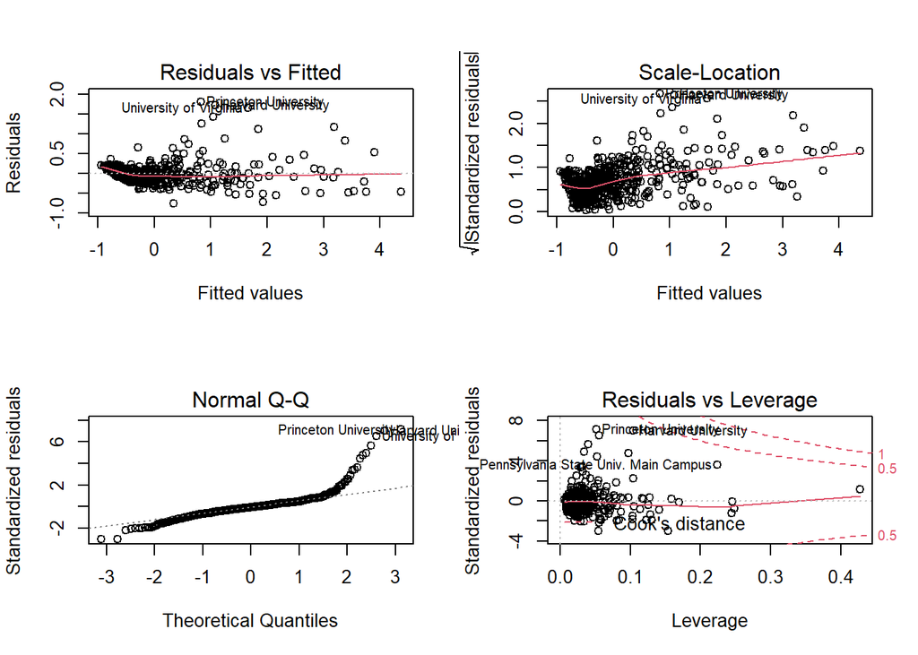

```r
# See the Plots
layout(matrix(c(1,2,3,4),2,2)) # optional 4 graphs/page
plot(lm_1)
```

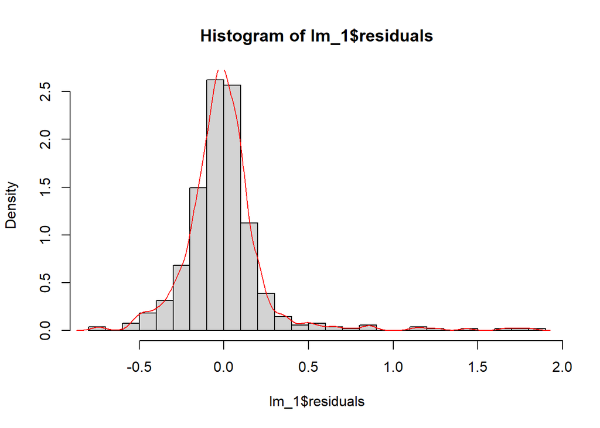

```r
layout(matrix(1,1))
#Check Normality of residuals
hist(lm_1$residuals,probability = T,breaks=25)
lines(density(lm_1$residuals),col="red")
```

```r
#Residuals distribution are right skewed!
```

```r
library(moments)
jarque.test(lm_1$residuals)
```

```
##
##  Jarque-Bera Normality Test
##
## data:  lm_1$residuals
## JB = 5859.3, p-value < 2.2e-16
## alternative hypothesis: greater
```

```r
anscombe.test(lm_1$residuals)
```

```
##
##  Anscombe-Glynn kurtosis test
##
## data:  lm_1$residuals
## kurt = 18.193, z = 11.516, p-value < 2.2e-16
## alternative hypothesis: kurtosis is not equal to 3
```

The result of both above tests rejects the normality. The residuals are not normal.

Unequal variance of Residuals => Heteroscedasticity problem !!

```r
# Predict the results with model 1
pred_lm_1 <- predict(lm_1,test)
abs_err_lm_1 <- abs(pred_lm_1-test$Apps)
MSE_lm_1<-mean((test$Apps-pred_lm_1) ^ 2)
rmse_lm_1 <- sqrt(MSE_lm_1)
```

MSE_lm_1 = 0.0537785.

RMSE_lm_1 = 0.231902.

**Note**： **Box_cox transformation** was applied and the results were checked.

This could not solve the **Normality** of residuals and the RMSE was obtained higher than the first model. Linear regression model is not a good model for current dataset, however, With the assumption that t-test results are valid, the variable selection was done.

### C_1: Linear Regression _ Choosing variables based on t-test

```r
lm_2 <- lm(Apps ~ Private + Accept + Enroll + Top10perc + Top25perc +
             F.Undergrad + P.Undergrad + Outstate + Room.Board + PhD + Expend + Grad.Rate ,
           data = train)

# The P-Value of Outstate in first model is marginal, but its p-value for second model is significant.
summary(lm_2)
```

```
##
## Call:
## lm(formula = Apps ~ Private + Accept + Enroll + Top10perc + Top25perc +
##     F.Undergrad + P.Undergrad + Outstate + Room.Board + PhD +
##     Expend + Grad.Rate, data = train)
##
## Residuals:
##      Min       1Q   Median       3Q      Max
## -0.76918 -0.11115 -0.01377  0.08364  1.81706
##
## Coefficients:
##             Estimate Std. Error t value Pr(>|t|)
## (Intercept)  0.11076    0.03128   3.541 0.000434 ***
## PrivateYes  -0.15671    0.04016  -3.902 0.000108 ***
## Accept       0.85295    0.03830  22.271  < 2e-16 ***
## Enroll      -0.15353    0.05542  -2.770 0.005798 **
## Top10perc    0.22225    0.02898   7.669 8.38e-14 ***
## Top25perc   -0.07490    0.02642  -2.835 0.004751 **
## F.Undergrad  0.14277    0.04571   3.123 0.001888 **
## P.Undergrad  0.02698    0.01340   2.013 0.044628 *
## Outstate    -0.05795    0.02283  -2.538 0.011426 *
## Room.Board   0.04829    0.01495   3.229 0.001320 **
## PhD         -0.04855    0.01543  -3.147 0.001742 **
## Expend       0.08542    0.01769   4.829 1.80e-06 ***
## Grad.Rate    0.05130    0.01524   3.366 0.000820 ***
## ---
## Signif. codes:  0 '***' 0.001 '**' 0.01 '*' 0.05 '.' 0.1 ' ' 1
##
## Residual standard error: 0.2604 on 529 degrees of freedom
## Multiple R-squared:  0.9187, Adjusted R-squared:  0.9168
## F-statistic: 497.9 on 12 and 529 DF,  p-value: < 2.2e-16
```

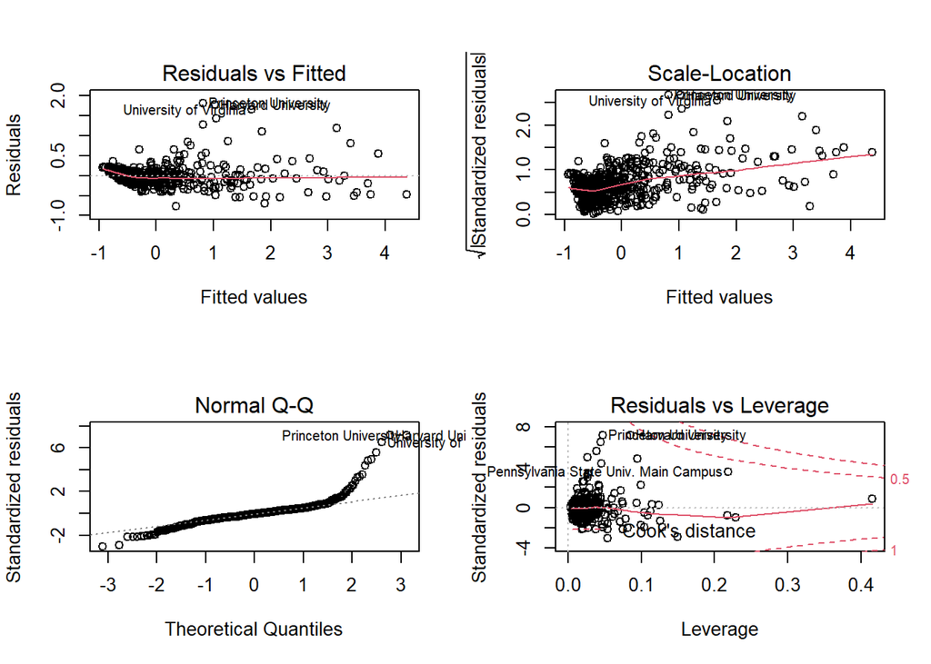

```r
#Plots:
layout(matrix(c(1,2,3,4),2,2)) # optional 4 graphs/page
plot(lm_2)
```

```r
layout(matrix(1,1))
```

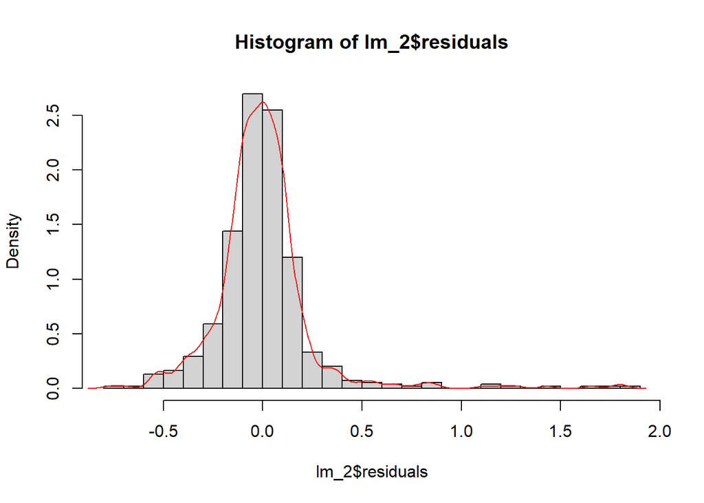

```r
#Check Normality of residuals
# residuals distribution
hist(lm_2$residuals,probability = T,breaks=25)
lines(density(lm_2$residuals),col="red")
```

Residuals distribution are right skewed.

In Q-Q plot, right and left sections we see the observations do not follow normal distribution.

```r
jarque.test(lm_2$residuals)
```

```
##
##  Jarque-Bera Normality Test
##
## data:  lm_2$residuals
## JB = 6009.7, p-value < 2.2e-16
## alternative hypothesis: greater
```

```r
anscombe.test(lm_2$residuals)
```

```
##
##  Anscombe-Glynn kurtosis test
##
## data:  lm_2$residuals
## kurt = 18.406, z = 11.553, p-value < 2.2e-16
## alternative hypothesis: kurtosis is not equal to 3
```

```r
car :: vif(lm_2)
```

```
##     Private      Accept      Enroll   Top10perc   Top25perc F.Undergrad
##    2.559081    9.802171   23.550005    6.742212    5.807830   16.575376
## P.Undergrad    Outstate  Room.Board         PhD      Expend   Grad.Rate
##    1.600707    4.135316    1.842077    1.887479    2.453633    1.783243
```

```r
# Predict the results with model 2
pred_lm_2 <- predict(lm_2,test)
abs_err_lm_2 <- abs(pred_lm_2-test$Apps)
MSE_lm_2<-mean((test$Apps-pred_lm_2) ^ 2)
rmse_lm_2 <- sqrt(MSE_lm_2)
```

MSE_lm_2 = 0.0527958.

RMSE_lm_2 = 0.2297734.

Residuals are not normally distributed.

According to the plots Heteroscedasticity is still not resolved. Besides, the residuals are not normal.

The VIF is more than 10 for Enroll and F.Undergrad => Multicollinearity problem.

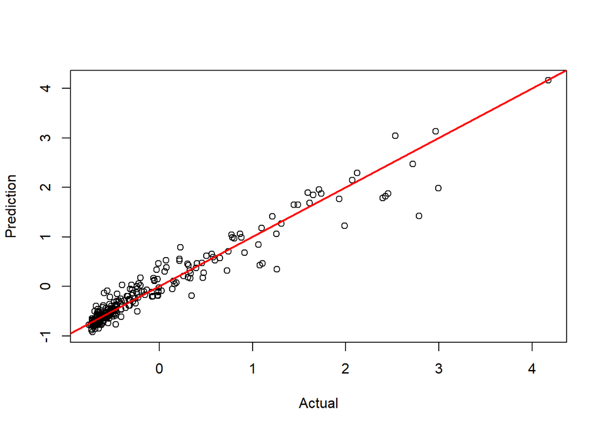

```r
# Actual vs predicted
plot(test$Apps, pred_lm_2, xlab = "Actual", ylab = "Prediction")
abline(a = 0, b = 1, col = "red", lwd = 2)
```

### C-2: step-wise method and k-fold cross validation

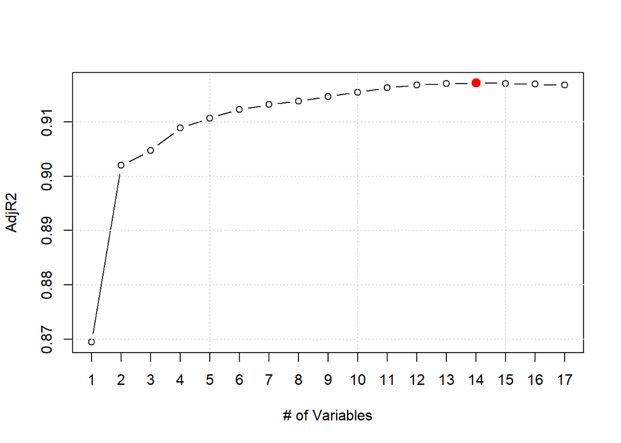

```r
bestsub_1<-regsubsets(Apps~.,nvmax =17,data=train,method='exhaustive')
#Model Selection
#With R-squared
plot(summary(bestsub_1)$adjr2,
     type = "b",
     xlab = "# of Variables",
     ylab = "AdjR2",
     xaxt = 'n',
     xlim = c(1, 17)); grid()
axis(1, at = 1:17, labels = 1:17)

points(which.max(summary(bestsub_1)$adjr2),
       summary(bestsub_1)$adjr2[which.max(summary(bestsub_1)$adjr2)],
       col = "red", cex = 2, pch = 20)
```

The adjusted R-squared is maximum with 14 variables.

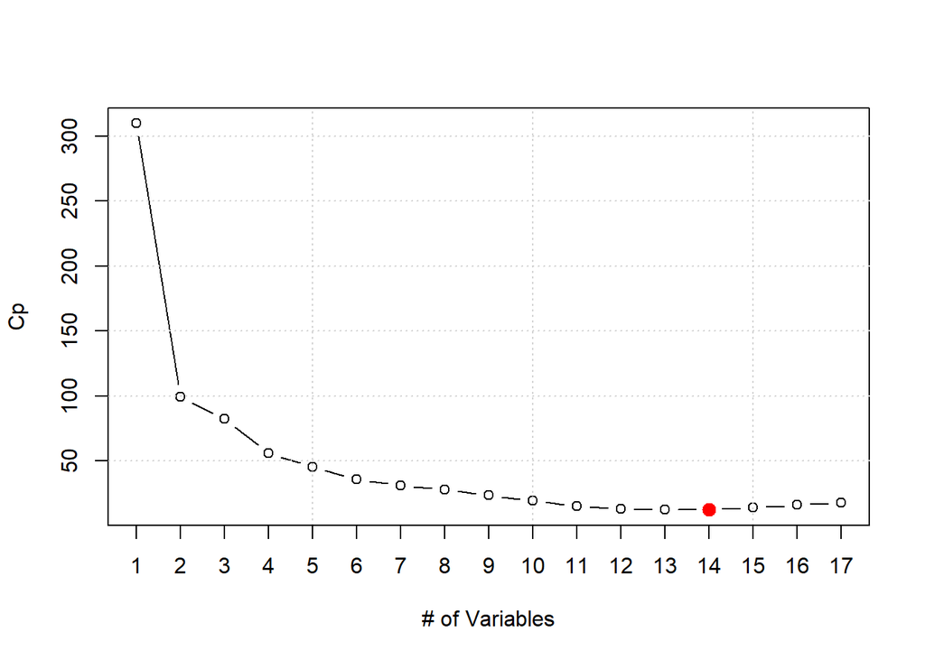

```r
plot(summary(bestsub_1)$cp,
     type = "b",
     xlab = "# of Variables",
     ylab = "Cp",
     xaxt = 'n',
     xlim = c(1, 17)); grid()
axis(1, at = 1:17, labels = 1:17)

points(which.min(summary(bestsub_1)$cp),
       summary(bestsub_1)$cp[which.min(summary(bestsub_1)$cp)],
       col = "red", cex = 2, pch = 20)
```

The Cp is minimum with 14 variables.

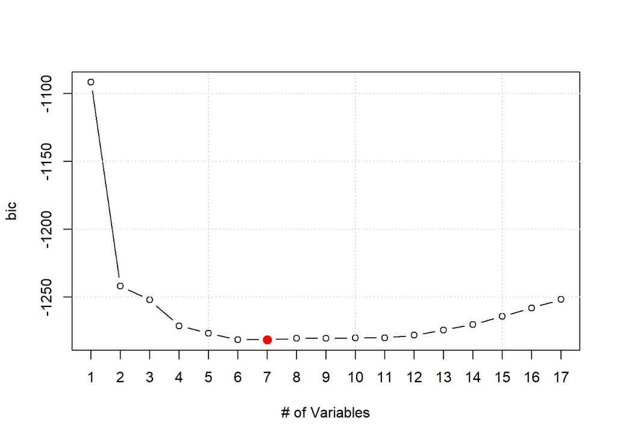

```r
plot(summary(bestsub_1)$bic,
     type = "b",
     xlab = "# of Variables",
     ylab = "bic",
     xaxt = 'n',
     xlim = c(1, 17)); grid()
axis(1, at = 1:17, labels = 1:17)

points(which.min(summary(bestsub_1)$bic),
       summary(bestsub_1)$bic[which.min(summary(bestsub_1)$bic)],
       col = "red", cex = 2, pch = 20)
```

The BIC is minimum with 7 variables.

Coefficients of the best model was selected based on adjusted R-squared and Cp. Although variable selection can be done based on BIC, we are to going to use maximum variables in our model and keep more information in model.

```r
coef(bestsub_1, 14)
```

```
## (Intercept)  PrivateYes      Accept      Enroll   Top10perc   Top25perc
##  0.10211470 -0.14512603  0.83563343 -0.13816574  0.22197844 -0.07142325
## F.Undergrad P.Undergrad    Outstate  Room.Board         PhD   S.F.Ratio
##  0.13658504  0.02654965 -0.04494144  0.04480314 -0.04863529  0.02423194
## perc.alumni      Expend   Grad.Rate
## -0.02184100  0.09770963  0.05678420
```

```r
bestsub_2 <- lm(Apps ~ Private+ Accept + Enroll + Top10perc + Top25perc + F.Undergrad + P.Undergrad +
                  Outstate + Room.Board + PhD + S.F.Ratio + perc.alumni + Expend + Grad.Rate ,
                data = train)
```

```r
pred_bestsub <- predict(bestsub_2, test)
#Absolute error, MSE, RMSE-------
abs_err_bestsub <- abs(pred_bestsub - test$Apps)
MSE_bestsub<- mean((test$Apps-pred_bestsub) ^ 2)
rmse_bestsub <- sqrt(mean((test$Apps-pred_bestsub) ^ 2))
```

MSE_bestsub = 0.0537319.

RMSE_bestsub = 0.2318014.

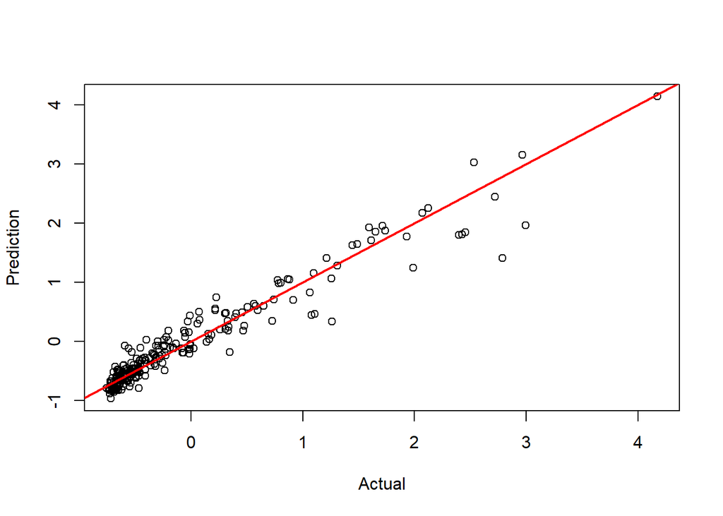

```r
#Actual vs. Predicted
plot(test$Apps, pred_bestsub, xlab = "Actual", ylab = "Prediction")
abline(a = 0, b = 1, col = "red", lwd = 2)
```

### Forward and backward Stepwise Selection

```r
fwd_1 <- regsubsets(Apps ~ ., nvmax = 17, data = train, method = "forward")
```

Max_R2_adj = 14.

Min_Cp= 14.

Min_BIC = 7.

Based on adjusted R-squared the model with 14 variable was biult.

```r
coef(fwd_1,14)
```

```
## (Intercept)  PrivateYes      Accept      Enroll   Top10perc   Top25perc
##  0.10211470 -0.14512603  0.83563343 -0.13816574  0.22197844 -0.07142325
## F.Undergrad P.Undergrad    Outstate  Room.Board         PhD   S.F.Ratio
##  0.13658504  0.02654965 -0.04494144  0.04480314 -0.04863529  0.02423194
## perc.alumni      Expend   Grad.Rate
## -0.02184100  0.09770963  0.05678420
```

```r
bestsub_fwd <- lm(Apps ~ Private + Accept + Enroll + Top10perc + Top25perc + F.Undergrad +
                    P.Undergrad + Outstate + Room.Board + PhD + S.F.Ratio + perc.alumni + Expend + Grad.Rate,
                  data = train)
pred_bestsub_fwd  <- predict(bestsub_fwd, test)
#Errors of Model on Test
abs_err_bestsub_fwd <- abs(pred_bestsub_fwd - test$Apps)
MSE_bestsub_fwd<- mean((test$Apps-pred_bestsub_fwd) ^ 2)
rmse_bestsub_fwd <- sqrt(mean((test$Apps-pred_bestsub_fwd) ^ 2))
```

MSE_bestsub_fwd = 0.0537319.

RMSE_bestsub_fwd = 0.2318014.

```r
#Backward Stepwise Selection
bwd_1 <- regsubsets(Apps ~ ., nvmax = 17, data = train, method = "backward")
```

Max_var_R2_adj = 14.

Min_Cp= 14.

Min_BIC = 7.

The Coefficient are the same with Forward Stepwise selection, therefore just one model was biult.

### K-fold Cross-Validation Approach in “exhaustive” method

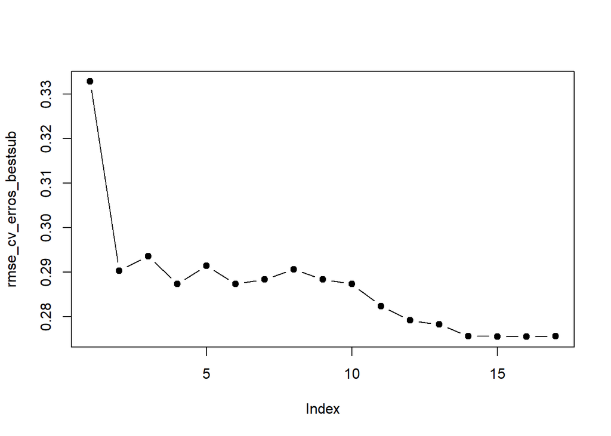

```r
k <- 10
set.seed(1234)
folds <- sample(1:k, nrow(train), rep = TRUE)
cv_errors <- matrix(NA, k, 17, dimnames = list(NULL , paste(1:17)))
#Create prediction function for regsubsets()
#Prediction function
predict_regsubsets <- function(object, newdata, id) {
  reg_formula <- as.formula(object$call[[2]])
  mat    <- model.matrix(reg_formula, newdata)
  coef_i <- coef(object, id = id)
  mat[, names(coef_i)] %*% coef_i
}

set.seed(123)
for(i in 1:k){
  best_fit <- regsubsets(Apps ~ . , data = train[folds != i,], nvmax = 17, method = "exhaustive")
  for(j in 1:17){
    pred <- predict_regsubsets(best_fit, newdata = train[folds == i,], id = j)
    cv_errors[i, j] <- mean((train$Apps[folds == i] - pred) ^ 2)
  }
}
mean_cv_erros <- apply(cv_errors, 2, mean)

rmse_cv_erros_bestsub <-  sqrt(apply(cv_errors, 2, mean))
plot(rmse_cv_erros_bestsub, pch = 19, type = "b")
```

The graph shows that RMSE of errors will be minimized with 16 variables with k-fold cross validation method.

```r
#Coefficients of the best model

coef(bestsub_1, 16)
```

```
##  (Intercept)   PrivateYes       Accept       Enroll    Top10perc    Top25perc
##  0.103372612 -0.146607751  0.834363397 -0.137143824  0.221000306 -0.069289519
##  F.Undergrad  P.Undergrad     Outstate   Room.Board        Books          PhD
##  0.137582945  0.026682450 -0.044181790  0.046587240 -0.005213215 -0.043723865
##     Terminal    S.F.Ratio  perc.alumni       Expend    Grad.Rate
## -0.008312214  0.024224604 -0.021872021  0.098518760  0.056183640
```

```r
bestsub_cv_1 <- lm(Apps~Private+ Accept + Enroll + Top10perc + Top25perc + F.Undergrad + P.Undergrad +
                     Outstate + Room.Board + Books + PhD + Terminal + S.F.Ratio + perc.alumni +
                     Expend + Grad.Rate,
                   data = train)

#Test the Model----------------------------------
#Model: m4
#Prediction
pred_bestsub_cv <- predict(bestsub_cv_1, test)

#Errors
abs_err_bestsub_cv <- abs(pred_bestsub_cv - test$Apps)
MSE_bestsub_cv<- mean((test$Apps-pred_bestsub_cv) ^ 2)
rmse_bestsub_cv <- sqrt(mean((test$Apps-pred_bestsub_cv) ^ 2))
```

MSE_bestsub_cv = 0.0537691.

RMSE_bestsub_cv = 0.2318816.

### Best Sub Selection Using Trimmed Train and CV

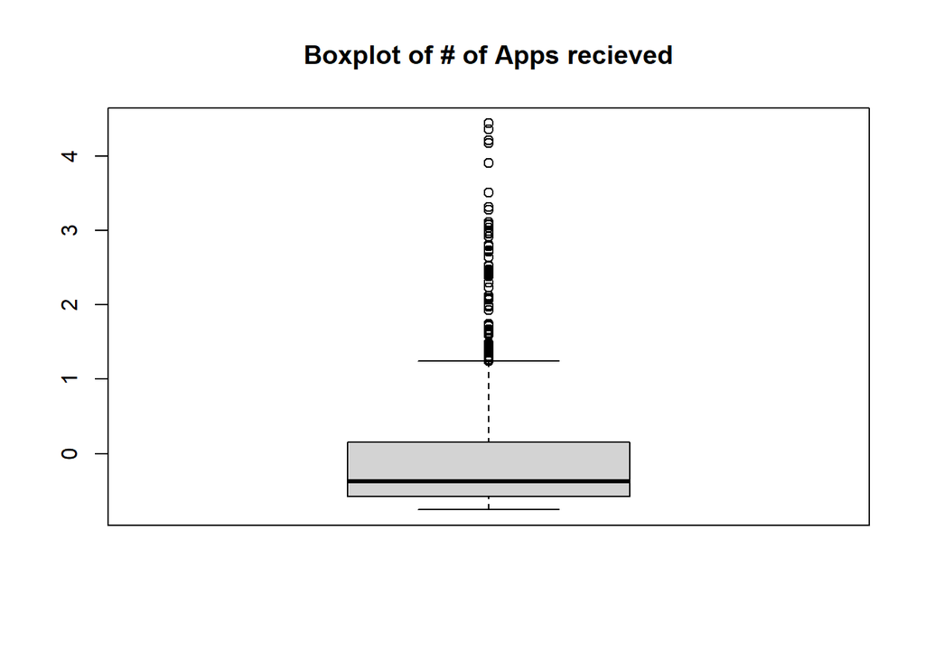

```r
#Train dataset without outliers for further investigation.
#Identify outlier
boxplot(data_3$Apps,main="Boxplot of # of Apps recieved")
```

```r
tukey_ul<-quantile(data_3$Apps,probs = 0.75)+1.5*IQR(data_3$Apps)
sum(data_3$Apps>tukey_ul)
```

```
## [1] 71
```

```r
round(sum(data_3$Apps>tukey_ul)/nrow(data_3)*100,2)
```

```
## [1] 9.16
```

About 9 percent of the total data in Apps variable are outliers. In the Following, the model performance with elimination of outliers was checked.

```r
trimmed_train<-train[train$Apps<tukey_ul,]
dim(trimmed_train)
```

```
## [1] 494  18
```

```r
trimmed_bestsub_1 <- regsubsets(Apps ~ . , nvmax = 17, data = trimmed_train, method = "exhaustive")
```

Max_var_R2_adj = 13.

Min_Cp= 12.

Min_BIC = 10.

```r
coef(trimmed_bestsub_1,13)
```

```
##  (Intercept)   PrivateYes       Accept       Enroll    Top10perc  F.Undergrad
##  0.015971005 -0.090412820  0.861796853 -0.150689118  0.062000712  0.076250347
##  P.Undergrad     Outstate   Room.Board        Books          PhD    S.F.Ratio
##  0.023040063 -0.032872066  0.018749286  0.005959155 -0.015275020  0.029788208
##       Expend    Grad.Rate
##  0.072234243  0.028277485
```

```r
trimmed_bestsub_2 <- lm(Apps ~ Private + Accept + Enroll + Top10perc + F.Undergrad +
                          P.Undergrad + Outstate + Room.Board + Books + PhD + S.F.Ratio +
                          Expend + Grad.Rate, data = trimmed_train)
summary(trimmed_bestsub_2)
```

```
##
## Call:
## lm(formula = Apps ~ Private + Accept + Enroll + Top10perc + F.Undergrad +
##     P.Undergrad + Outstate + Room.Board + Books + PhD + S.F.Ratio +
##     Expend + Grad.Rate, data = trimmed_train)
##
## Residuals:
##      Min       1Q   Median       3Q      Max
## -0.40118 -0.06439 -0.00926  0.04437  0.69681
##
## Coefficients:
##              Estimate Std. Error t value Pr(>|t|)
## (Intercept)  0.015971   0.017065   0.936 0.349792
## PrivateYes  -0.090413   0.022142  -4.083 5.20e-05 ***
## Accept       0.861797   0.029462  29.251  < 2e-16 ***
## Enroll      -0.150689   0.040886  -3.686 0.000254 ***
## Top10perc    0.062001   0.010271   6.037 3.15e-09 ***
## F.Undergrad  0.076250   0.033829   2.254 0.024647 *
## P.Undergrad  0.023040   0.010218   2.255 0.024593 *
## Outstate    -0.032872   0.012588  -2.611 0.009298 **
## Room.Board   0.018749   0.008180   2.292 0.022326 *
## Books        0.005959   0.005485   1.086 0.277836
## PhD         -0.015275   0.008130  -1.879 0.060862 .
## S.F.Ratio    0.029788   0.008458   3.522 0.000469 ***
## Expend       0.072234   0.012088   5.976 4.47e-09 ***
## Grad.Rate    0.028277   0.008032   3.521 0.000471 ***
## ---
## Signif. codes:  0 '***' 0.001 '**' 0.01 '*' 0.05 '.' 0.1 ' ' 1
##
## Residual standard error: 0.1335 on 480 degrees of freedom
## Multiple R-squared:   0.92,  Adjusted R-squared:  0.9178
## F-statistic: 424.5 on 13 and 480 DF,  p-value: < 2.2e-16
```

```r
# Test the Model----------------------------------
#Prediction
pred_trimmed_bestsub  <- predict(trimmed_bestsub_2, test)
#Errors
abs_err_trimmed_bestsub <- abs(pred_trimmed_bestsub - test$Apps)
MSE_bestsub_trimmed<- mean((test$Apps-pred_trimmed_bestsub) ^ 2)
rmse_bestsub_trimmed <- sqrt(mean((test$Apps-pred_trimmed_bestsub) ^ 2))
```

MSE_bestsub_trimmed = 0.0714322.

RMSE_bestsub_trimmed = 0.267268.

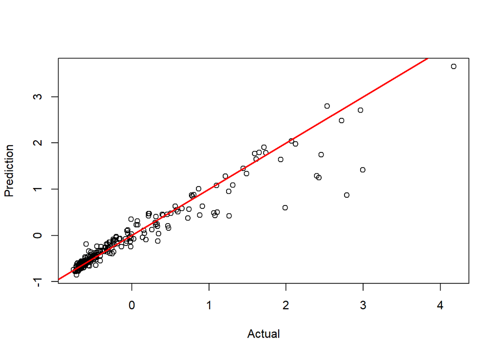

```r
#Actual vs. Predicted
plot(test$Apps, pred_trimmed_bestsub, xlab = "Actual", ylab = "Prediction")
abline(a = 0, b = 1, col = "red", lwd = 2)
```

### D: ridge regression model

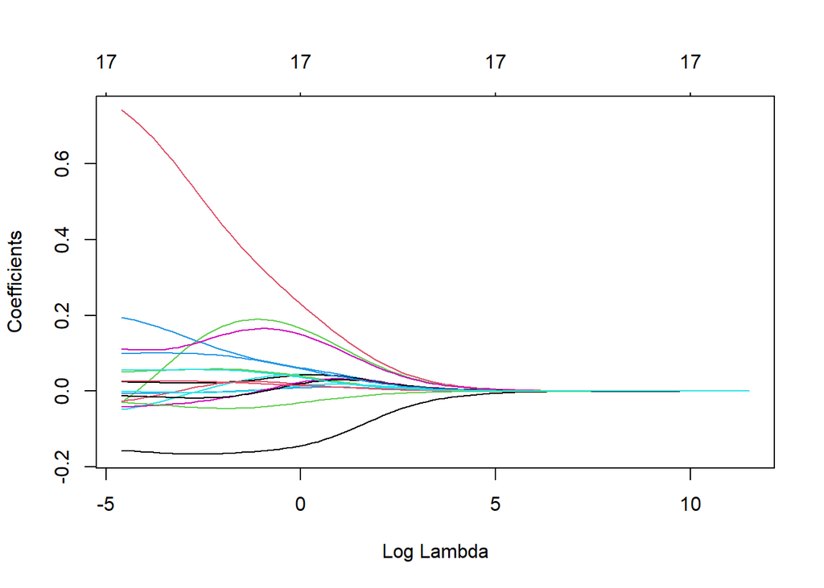

```r
x <- model.matrix(Apps ~ ., data = train)[, -1] #remove intercept
y <- train$Apps

lambda_grid <- 10 ^ seq(5, -2, length = 100)

#Apply Ridge Regression
ridgereg_1 <- glmnet(x, y, alpha = 0, lambda = lambda_grid)

#Plot Reg. Coefficients vs. Log Lambda
plot(ridgereg_1, xvar = "lambda")
```

```r
#Apply Ridge Regression with Cross validation to choose the best model
set.seed(123)
ridge_cv <- cv.glmnet(x, y, alpha = 0, lambda = lambda_grid, nfolds = 10)
```

```r
#The mean cross-validated error
ridge_cv$cvm
```

```
##   [1] 0.81587407 0.81586504 0.81585441 0.81584190 0.81582718 0.81580986
##   [7] 0.81578948 0.81576550 0.81573728 0.81570407 0.81566499 0.81561900
##  [13] 0.81556489 0.81550123 0.81542631 0.81533817 0.81523446 0.81511245
##  [19] 0.81496890 0.81480003 0.81460138 0.81436772 0.81409290 0.81376970
##  [25] 0.81338965 0.81294280 0.81241751 0.81180011 0.81107462 0.81022233
##  [31] 0.80922139 0.80804630 0.80666733 0.80504992 0.80315753 0.80094259
##  [37] 0.79834652 0.79531141 0.79176705 0.78763351 0.78282035 0.77722603
##  [43] 0.77073756 0.76323059 0.75457014 0.74461219 0.73320635 0.72019999
##  [49] 0.70544406 0.68880080 0.67015349 0.64941836 0.62655699 0.60159103
##  [55] 0.57461459 0.54580481 0.51542757 0.48383637 0.45146276 0.41879761
##  [61] 0.38636410 0.35468499 0.32424797 0.29546691 0.26867323 0.24409613
##  [67] 0.22185114 0.20195860 0.18434858 0.16889441 0.15546013 0.14384832
##  [73] 0.13386090 0.12531082 0.11803327 0.11184755 0.10659708 0.10214120
##  [79] 0.09835470 0.09512306 0.09235392 0.08995273 0.08785208 0.08598571
##  [85] 0.08431740 0.08281954 0.08147083 0.08025831 0.07917303 0.07821193
##  [91] 0.07736831 0.07664062 0.07602839 0.07551155 0.07509381 0.07475595
##  [97] 0.07449539 0.07430087 0.07416201 0.07406178
```

```r
#Estimate of standard error of cvm.
ridge_cv$cvsd
```

```
##   [1] 0.088979528 0.088978758 0.088977851 0.088976783 0.088975528 0.088974049
##   [7] 0.088972310 0.088970263 0.088967855 0.088965021 0.088961686 0.088957761
##  [13] 0.088953143 0.088947710 0.088941316 0.088933793 0.088924941 0.088914527
##  [19] 0.088902274 0.088887859 0.088870901 0.088850953 0.088827490 0.088799893
##  [25] 0.088767438 0.088729275 0.088684405 0.088631659 0.088569666 0.088496821
##  [31] 0.088411247 0.088310751 0.088192775 0.088054335 0.087891345 0.087702461
##  [37] 0.087479834 0.087219334 0.086914819 0.086559266 0.086144684 0.085662041
##  [43] 0.085101202 0.084450904 0.083698767 0.082831374 0.081834435 0.080693060
##  [49] 0.079392173 0.077917096 0.076254309 0.074392420 0.072323248 0.070043134
##  [55] 0.067554190 0.064865485 0.061993946 0.058964786 0.055811273 0.052573714
##  [61] 0.049297643 0.046031314 0.042822769 0.039717195 0.036750313 0.033956491
##  [67] 0.031356120 0.028961583 0.026777868 0.024793734 0.023009863 0.021409373
##  [73] 0.019977288 0.018694389 0.017551122 0.016529788 0.015617560 0.014803286
##  [79] 0.014077765 0.013431066 0.012856681 0.012348392 0.011898709 0.011500953
##  [85] 0.011154401 0.010854210 0.010598132 0.010383876 0.010208580 0.010071099
##  [91] 0.009967551 0.009896555 0.009852937 0.009834627 0.009836018 0.009855300
##  [97] 0.009886365 0.009926329 0.009972851 0.010022345
```

```r
#value of lambda that gives minimum cvm
ridge_cv$lambda.min
```

```
## [1] 0.01
```

```r
#Coefficients of regression w/ best_lambda
ridgereg_2 <- glmnet(x, y, alpha = 0, lambda = ridge_cv$lambda.min)
coef(ridgereg_2)
```

```
## 18 x 1 sparse Matrix of class "dgCMatrix"
##                        s0
## (Intercept)  0.1097438434
## PrivateYes  -0.1559937804
## Accept       0.7406064255
## Enroll      -0.0293188221
## Top10perc    0.1950640399
## Top25perc   -0.0483052404
## F.Undergrad  0.1115721035
## P.Undergrad  0.0247019710
## Outstate    -0.0265132857
## Room.Board   0.0509837098
## Books       -0.0052881623
## Personal    -0.0007385187
## PhD         -0.0409562330
## Terminal    -0.0119953621
## S.F.Ratio    0.0258543338
## perc.alumni -0.0293450247
## Expend       0.0996486586
## Grad.Rate    0.0560223977
```

```r
#Test the Ridge Regression Model----------------------------------
#Prediction
#Create model matrix for test
x_test <- model.matrix(Apps ~ ., data = test)[, -1]#remove intercept
pred_ridgereg <- predict(ridgereg_2, s = ridge_cv$lambda.min, newx = x_test)
```

```r
#Errors
abs_err_ridgereg <- abs(pred_ridgereg - test$Apps)
MSE_ridgreg<-mean((test$Apps-pred_ridgereg)^2)
rmse_bestsub_ridgereg <- sqrt(mean((test$Apps-pred_ridgereg)^2))
```

MSE_ridgreg = 0.0545004

RMSE_bestsub_ridgereg = 0.2334531

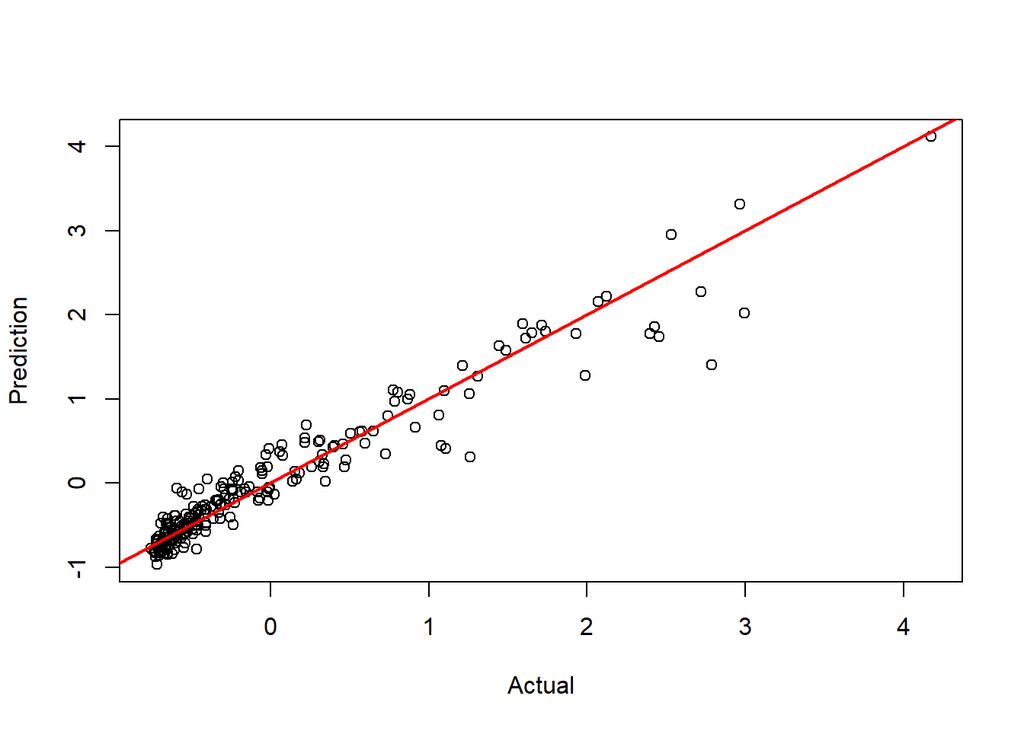

```r
#Actual vs. Predicted
plot(test$Apps, pred_ridgereg, xlab = "Actual", ylab = "Prediction")
abline(a = 0, b = 1, col = "red", lwd = 2)
```

### E: Lasso Regression

```r
#Apply Lasso Regression
lassoreg_1 <- glmnet(x, y, alpha = 1, lambda = lambda_grid)
dim(coef(lassoreg_1))
```

```
## [1]  18 100
```

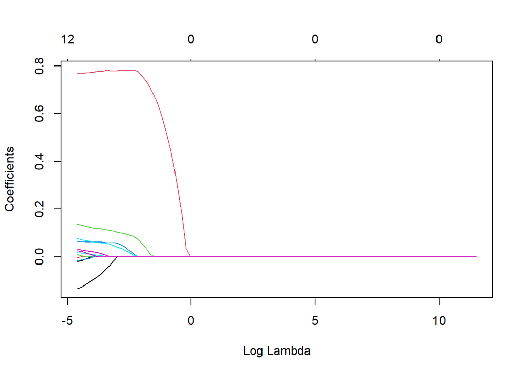

```r
#Plot Reg. Coefficients vs. Log Lambda
plot(lassoreg_1, xvar = "lambda")
```

```r
#Cross validation to choose the best model
set.seed(123)
lasso_cv<- cv.glmnet(x, y, alpha = 1, lambda = lambda_grid, nfolds = 10)
#The mean cross-validated error
lasso_cv$cvm
```

```
##   [1] 0.81592515 0.81592515 0.81592515 0.81592515 0.81592515 0.81592515
##   [7] 0.81592515 0.81592515 0.81592515 0.81592515 0.81592515 0.81592515
##  [13] 0.81592515 0.81592515 0.81592515 0.81592515 0.81592515 0.81592515
##  [19] 0.81592515 0.81592515 0.81592515 0.81592515 0.81592515 0.81592515
##  [25] 0.81592515 0.81592515 0.81592515 0.81592515 0.81592515 0.81592515
##  [31] 0.81592515 0.81592515 0.81592515 0.81592515 0.81592515 0.81592515
##  [37] 0.81592515 0.81592515 0.81592515 0.81592515 0.81592515 0.81592515
##  [43] 0.81592515 0.81592515 0.81592515 0.81592515 0.81592515 0.81592515
##  [49] 0.81592515 0.81592515 0.81592515 0.81592515 0.81592515 0.81592515
##  [55] 0.81592515 0.81592515 0.81592515 0.81592515 0.81592515 0.81592515
##  [61] 0.81592515 0.81592515 0.81592515 0.81592515 0.81592515 0.81592515
##  [67] 0.81592515 0.81592515 0.81592515 0.81592515 0.81592515 0.81592515
##  [73] 0.77261733 0.58826403 0.45377111 0.35678556 0.28686395 0.23646820
##  [79] 0.20015768 0.17400592 0.15517948 0.13908578 0.12286636 0.11122908
##  [85] 0.10320061 0.09740304 0.09267638 0.08898381 0.08633811 0.08425075
##  [91] 0.08248534 0.08101867 0.07990044 0.07905192 0.07840371 0.07794887
##  [97] 0.07740242 0.07666551 0.07595334 0.07541529
```

```r
#Estimate of standard error of cvm.
lasso_cv$cvsd
```

```
##   [1] 0.08898389 0.08898389 0.08898389 0.08898389 0.08898389 0.08898389
##   [7] 0.08898389 0.08898389 0.08898389 0.08898389 0.08898389 0.08898389
##  [13] 0.08898389 0.08898389 0.08898389 0.08898389 0.08898389 0.08898389
##  [19] 0.08898389 0.08898389 0.08898389 0.08898389 0.08898389 0.08898389
##  [25] 0.08898389 0.08898389 0.08898389 0.08898389 0.08898389 0.08898389
##  [31] 0.08898389 0.08898389 0.08898389 0.08898389 0.08898389 0.08898389
##  [37] 0.08898389 0.08898389 0.08898389 0.08898389 0.08898389 0.08898389
##  [43] 0.08898389 0.08898389 0.08898389 0.08898389 0.08898389 0.08898389
##  [49] 0.08898389 0.08898389 0.08898389 0.08898389 0.08898389 0.08898389
##  [55] 0.08898389 0.08898389 0.08898389 0.08898389 0.08898389 0.08898389
##  [61] 0.08898389 0.08898389 0.08898389 0.08898389 0.08898389 0.08898389
##  [67] 0.08898389 0.08898389 0.08898389 0.08898389 0.08898389 0.08898389
##  [73] 0.09328487 0.07075779 0.05396651 0.04245775 0.03460432 0.02924928
##  [79] 0.02558985 0.02308454 0.02137494 0.02048749 0.01884269 0.01761365
##  [85] 0.01665571 0.01595550 0.01555284 0.01506832 0.01467166 0.01420219
##  [91] 0.01380210 0.01347895 0.01323461 0.01301950 0.01282010 0.01268579
##  [97] 0.01255170 0.01242772 0.01221588 0.01199901
```

```r
#value of lambda that gives minimum cvm
lasso_cv$lambda.min
```

```
## [1] 0.01
```

```r
#Coefficients of regression w/ best_lambda
lassoreg_2 <- glmnet(x, y, alpha = 1, lambda = lasso_cv$lambda.min)
coef(lassoreg_2)
```

```
## 18 x 1 sparse Matrix of class "dgCMatrix"
##                       s0
## (Intercept)  0.096805281
## PrivateYes  -0.136289480
## Accept       0.766561788
## Enroll       .
## Top10perc    0.135618431
## Top25perc    .
## F.Undergrad  0.063481957
## P.Undergrad  0.016363447
## Outstate     .
## Room.Board   0.029341077
## Books        .
## Personal     .
## PhD         -0.022134949
## Terminal    -0.005211978
## S.F.Ratio    0.007118214
## perc.alumni -0.018221340
## Expend       0.074464315
## Grad.Rate    0.024608099
```

```r
#Test the Model----------------------------------
#Model: Lasso Regression
#Prediction
pred_lassoreg <- predict(lassoreg_2, s = lasso_cv$lambda.min, newx = x_test)

#Errors
abs_err_lassoreg <- abs(pred_lassoreg - test$Apps)
MSE_lassoreg<-mean((test$Apps-pred_lassoreg)^2)
rmse_bestsub_lassoreg <- sqrt(mean((test$Apps-pred_lassoreg)^2))
```

MSE_lassoreg = 0.0539471.

RMSE_bestsub_lassoreg = 0.2322651.

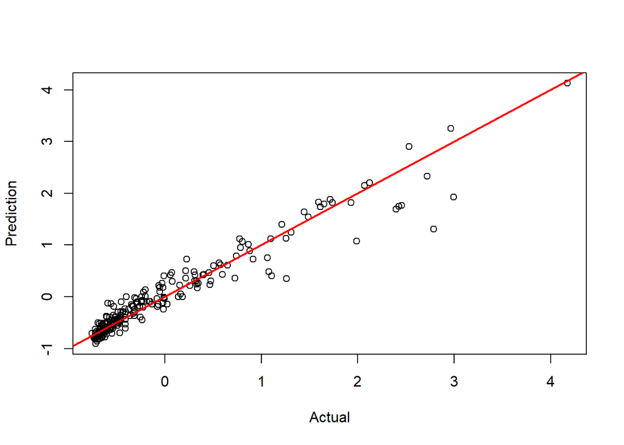

```r
#Actual vs. Predicted
plot(test$Apps, pred_lassoreg, xlab = "Actual", ylab = "Prediction")
abline(a = 0, b = 1, col = "red", lwd = 2)
```

### Model F: Decision Trees

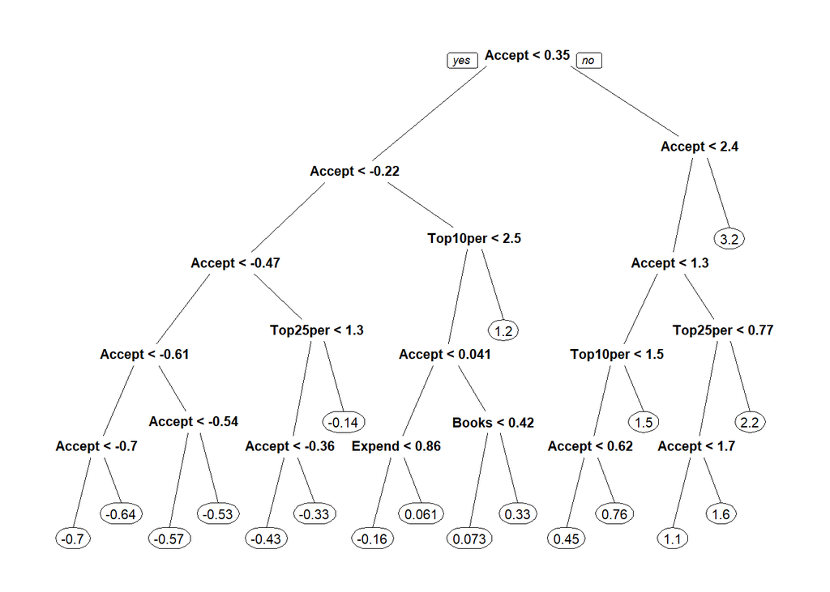

```r
tree_1 <- rpart(formula = Apps ~ . , data = train, cp = 0.00001, maxdepth = 5)
#Plot the tree
prp(tree_1)
```

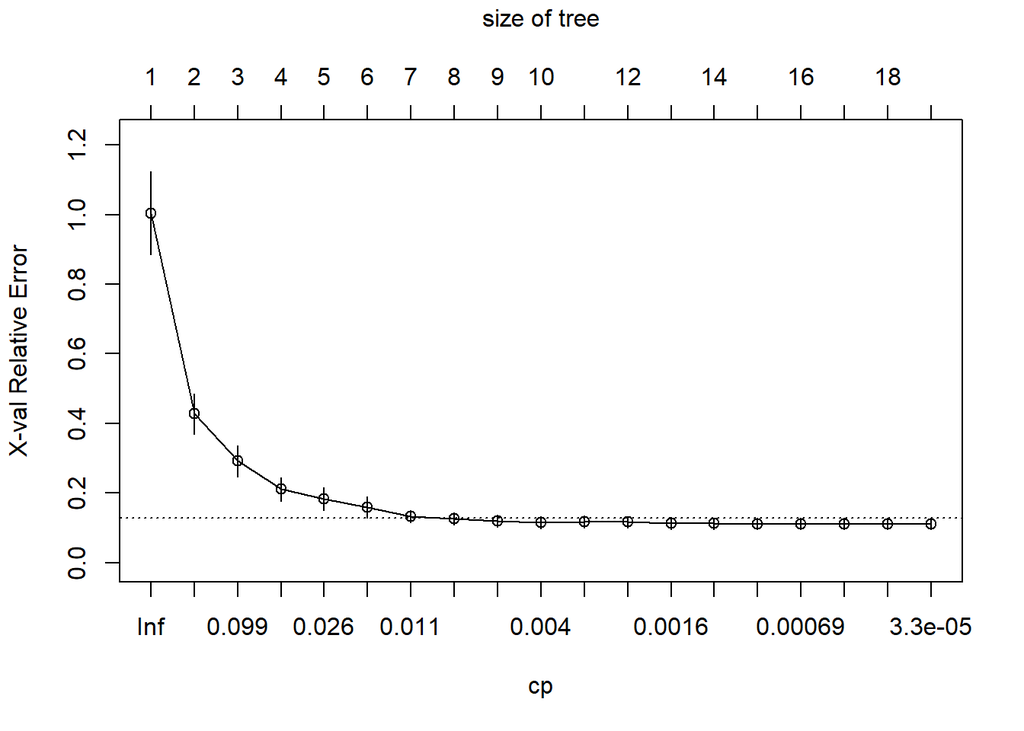

```r
#Prune the tree
plotcp(tree_1)
```

```r
tree_1$cptable[which.min(tree_1$cptable[,"xerror"])]
```

```
## [1] 1e-05
```

```r
tree_1_2 <- prune.rpart(tree_1,
                        cp = tree_1$cptable[which.min(tree_1$cptable[,"xerror"])])
#prp(tree_1_2)
pred_tree  <- predict(tree_1_2, test)
```

```r
#Errors
abs_err_tree <- abs(pred_tree - test$Apps)
MSE_tree<-mean((test$Apps-pred_tree)^2)
rmse_tree <- sqrt(mean((test$Apps-pred_tree)^2))
```

MSE_tree = 0.0569049.

RMSE_tree = 0.2385475.

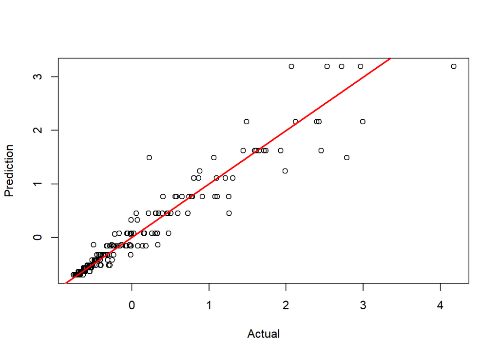

```r
#Actual vs. Predicted
plot(test$Apps, pred_tree, xlab = "Actual", ylab = "Prediction")
abline(a = 0, b = 1, col = "red", lwd = 2)
```

### Bagging

```r
set.seed(123)
bagging_1 <- randomForest(Apps ~ . , mtry = ncol(train) - 1, ntree = 500, data = train)
bagging_1
```

```
##
## Call:
##  randomForest(formula = Apps ~ ., data = train, mtry = ncol(train) -      1, ntree = 500)
##                Type of random forest: regression
##                      Number of trees: 500
## No. of variables tried at each split: 17
##
##           Mean of squared residuals: 0.06737905
##                     % Var explained: 91.72
```

```r
#Test the Model----------------------------------
#Prediction: M8 Bagging
pred_bagging  <- predict(bagging_1, test)

abs_err_bagging <- abs(pred_bagging - test$Apps)
MSE_bagging<-mean((test$Apps-pred_bagging)^2)
rmse_bagging <- sqrt(mean((test$Apps-pred_bagging)^2))
```

MSE_bagging = 0.0475816.

RMSE_bagging = 0.218132.

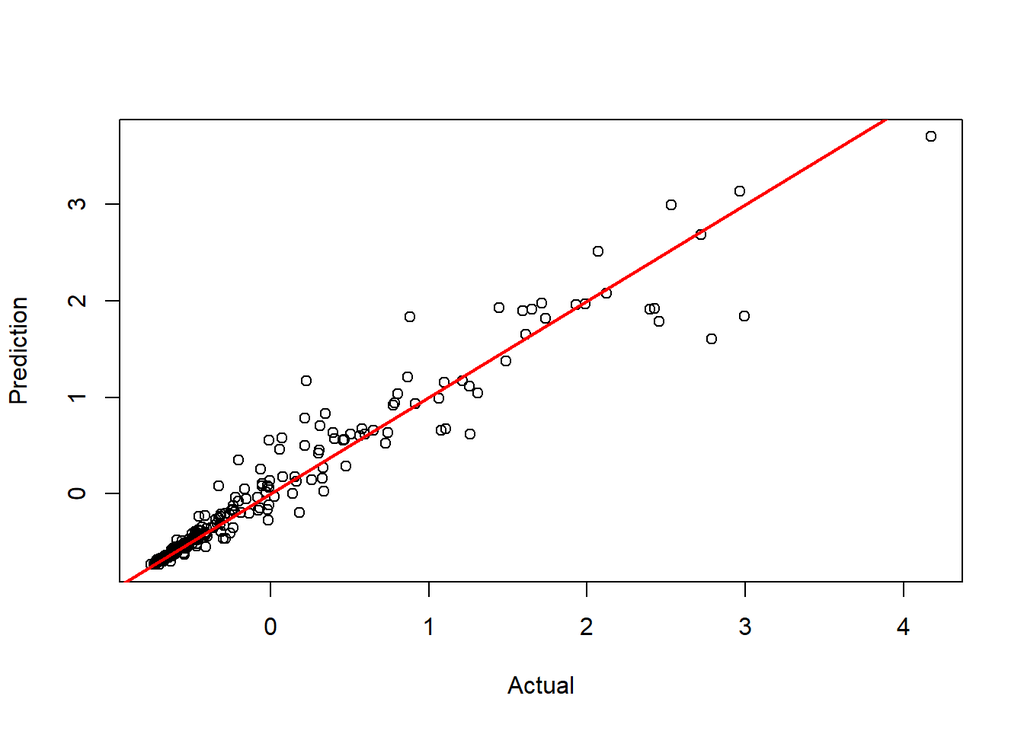

```r
#Actual vs. Predicted
plot(test$Apps, pred_bagging, xlab = "Actual", ylab = "Prediction")
abline(a = 0, b = 1, col = "red", lwd = 2)
```

### Model H: Random Forrest

```r
set.seed(123)
rf_1 <- randomForest(Apps ~ ., data = train, mtry = 6, ntree = 500, importance = TRUE)
#mtry   for regression = p/3 ~=6
rf_1
```

```
##
## Call:
##  randomForest(formula = Apps ~ ., data = train, mtry = 6, ntree = 500,      importance = TRUE)
##                Type of random forest: regression
##                      Number of trees: 500
## No. of variables tried at each split: 6
##
##           Mean of squared residuals: 0.06373528
##                     % Var explained: 92.17
```

```r
importance(rf_1)
```

```
##               %IncMSE IncNodePurity
## Private      4.769243      6.032447
## Accept      31.937743    173.498947
## Enroll      18.518094    111.342277
## Top10perc   10.957697      9.550145
## Top25perc   11.332632     16.224500
## F.Undergrad 13.251671     62.025835
## P.Undergrad  5.453957     13.230011
## Outstate    12.772365      8.268878
## Room.Board   6.661765      3.583185
## Books        1.185301      1.686702
## Personal     4.603198      2.204872
## PhD          4.922207      5.009155
## Terminal     4.442145      3.217306
## S.F.Ratio    5.589559      3.183735
## perc.alumni  3.824598      2.807310
## Expend       8.190166      8.004373
## Grad.Rate    7.902238      7.002891
```

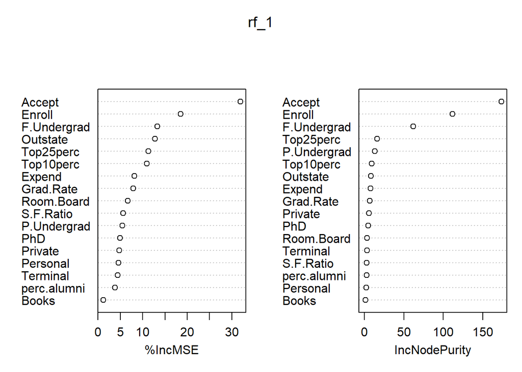

```r
varImpPlot(rf_1)
```

```r
set.seed(123)
rf_cv <- rfcv(train[, - c(2)],
              train$Apps,
              cv.fold = 10,
              step = 0.75,
              mtry = function(p) max(1, floor(sqrt(p))),
              recursive = FALSE)

str(rf_cv)
```

```
## List of 3
##  $ n.var    : num [1:9] 17 13 10 7 5 4 3 2 1
##  $ error.cv : Named num [1:9] 0.0722 0.0731 0.0631 0.067 0.0637 ...
##   ..- attr(*, "names")= chr [1:9] "17" "13" "10" "7" ...
##  $ predicted:List of 9
##   ..$ 17: num [1:542] 0.0765 -0.6126 1.5374 -0.3995 -0.5715 ...
##   ..$ 13: num [1:542] 0.104 -0.624 1.377 -0.367 -0.577 ...
##   ..$ 10: num [1:542] 0.0864 -0.6372 1.4669 -0.3859 -0.5876 ...
##   ..$ 7 : num [1:542] 0.075 -0.633 1.547 -0.381 -0.59 ...
##   ..$ 5 : num [1:542] 0.0994 -0.6378 1.3976 -0.4247 -0.5917 ...
##   ..$ 4 : num [1:542] 0.168 -0.638 1.402 -0.456 -0.596 ...
##   ..$ 3 : num [1:542] 0.204 -0.635 1.852 -0.412 -0.56 ...
##   ..$ 2 : num [1:542] 0.225 -0.644 1.87 -0.424 -0.577 ...
##   ..$ 1 : num [1:542] 0.0988 -0.642 1.114 -0.4405 -0.5947 ...
```

```r
#Vector of number of variables used at each step
rf_cv$n.var
```

```
## [1] 17 13 10  7  5  4  3  2  1
```

```r
#Corresponding vector of MSEs at each step
rf_cv$error.cv
```

```
##         17         13         10          7          5          4          3
## 0.07222177 0.07312268 0.06313800 0.06696374 0.06374584 0.07951983 0.13417398
##          2          1
## 0.13783935 0.14056002
```

```r
#Remove 7 variables based on Importance of Variables
sort(importance(rf_1)[,1])
```

```
##       Books perc.alumni    Terminal    Personal     Private         PhD
##    1.185301    3.824598    4.442145    4.603198    4.769243    4.922207
## P.Undergrad   S.F.Ratio  Room.Board   Grad.Rate      Expend   Top10perc
##    5.453957    5.589559    6.661765    7.902238    8.190166   10.957697
##   Top25perc    Outstate F.Undergrad      Enroll      Accept
##   11.332632   12.772365   13.251671   18.518094   31.937743
```

```r
#Regression formula
reg_formula <- as.formula(Apps ~ Accept + Enroll + F.Undergrad + Top25perc + Top10perc +
                            Room.Board + Outstate + Grad.Rate + Expend + S.F.Ratio)
#mtry   => floor(sqrt(10))

set.seed(123)
rf_2 <- randomForest(reg_formula, data = train, mtry = 3, ntree = 1000)
rf_2
```

```
##
## Call:
##  randomForest(formula = reg_formula, data = train, mtry = 3, ntree = 1000)
##                Type of random forest: regression
##                      Number of trees: 1000
## No. of variables tried at each split: 3
##
##           Mean of squared residuals: 0.06043224
##                     % Var explained: 92.57
```

```r
#Test the Model----------------------------------
#Prediction: M9 Random Forrest
pred_rf  <- predict(rf_2, test)
```

```r
#Errors
abs_err_rf <- abs(pred_rf - test$Apps)
MSE_rf<-mean((test$Apps-pred_rf)^2)
rmse_rf<-sqrt(mean((test$Apps-pred_rf)^2))
```

MSE_rf = 0.037206.

RMSE_rf = 0.1928885.

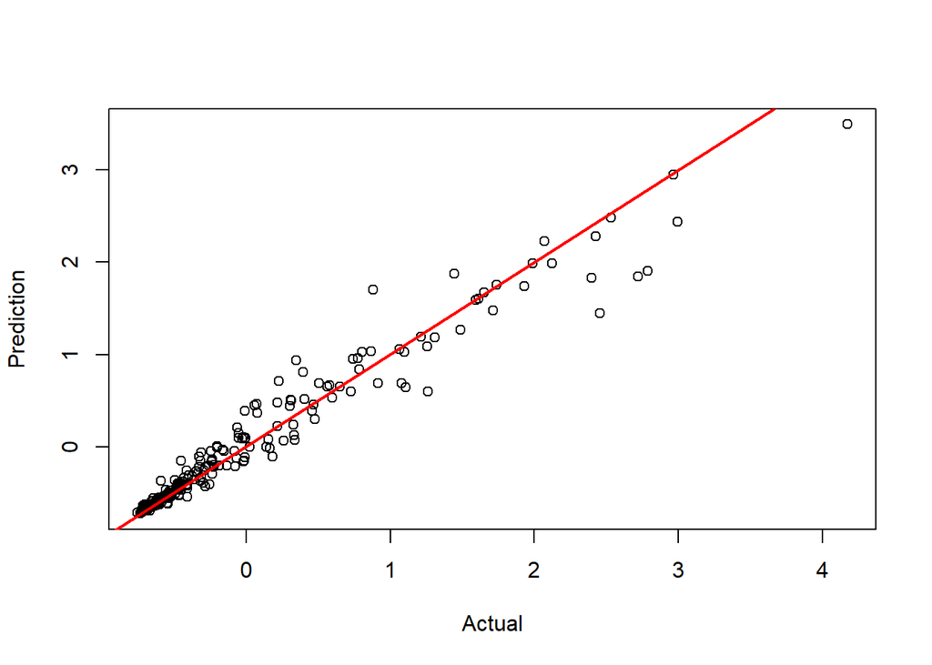

```r
#Actual vs. Predicted
plot(test$Apps, pred_rf, xlab = "Actual", ylab = "Prediction")
abline(a = 0, b = 1, col = "red", lwd = 2)
```

```r
set.seed(123)
#train GBM model
gbm_1 <- gbm(formula = Apps ~ .,
             distribution = "gaussian", #gaussian for regression problems
             data = train,
             n.trees = 10000, #the total number of trees to fit
             interaction.depth = 1, #1: stump, the maximum depth of each tree
             shrinkage = 0.001, #learning rate
             cv.folds = 5, #Number of cross-validation folds to perform
             n.cores = NULL, #will use all cores by default
             verbose = FALSE)
```

```r
#get MSE and compute RMSE
```

MSE = 0.0793993.

RMSE = 0.2817788.

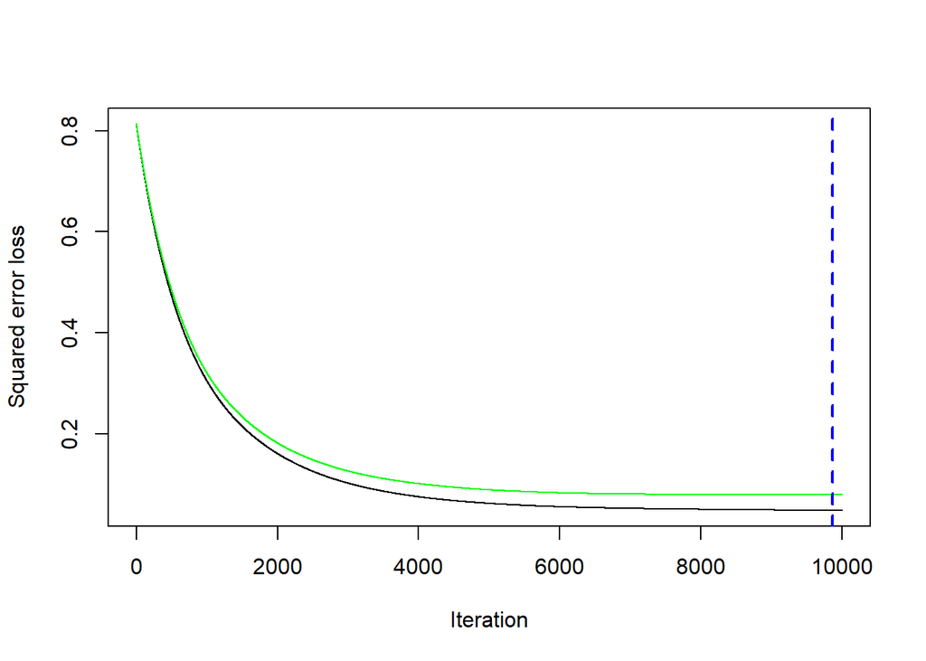

```
## [1] 9863
```

```r
#plot loss function as a result of n trees added to the ensemble
gbm.perf(gbm_1, method = "cv")
```

```r
#returns the estimated optimal number of iterations
```

```r
#Use different parameters
set.seed(123)
gbm_2 <- gbm(formula = Apps ~ .,
             distribution = "gaussian",
             data = train,
             n.trees = 10000,
             interaction.depth = 3,
             shrinkage = 0.1,
             cv.folds = 5,
             n.cores = NULL, #will use all cores by default
             verbose = FALSE)
```

```r
#get MSE and compute RMSE
```

MSE = 0.0674475.

RMSE = 0.2597066.

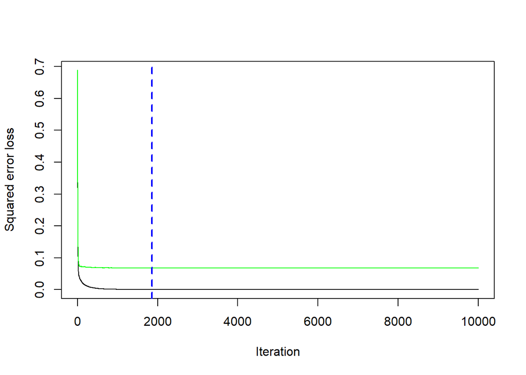

```
## [1] 1853
```

```r
#plot loss function as a result of n trees added to the ensemble
gbm.perf(gbm_2, method = "cv")
```

```r
#Tuning
#Create hyper-parameter grid
par_grid <- expand.grid(shrinkage = c(0.01, 0.1, 0.3),
                        interaction_depth = c(1, 3, 5), #the maximum depth of each tree
                        n_minobsinnode = c(5, 10, 15),  #the minimum number of observations in the                                      terminal nodes of the trees
                        bag_fraction = c(0.5, 0.7, 0.9) #stochastic gradient:bag.fraction < 1
                        )
nrow(par_grid)
```

```
## [1] 81
```

```r
#Grid search (train/validation approach)
for(i in 1:nrow(par_grid)) {
  set.seed(123)
  #train model
  gbm_tune <- gbm(formula = Apps ~ .,
                  distribution = "gaussian",
                  data = train,
                  n.trees = 5000,
                  interaction.depth = par_grid$interaction_depth[i],
                  shrinkage = par_grid$shrinkage[i],
                  n.minobsinnode = par_grid$n_minobsinnode[i],
                  bag.fraction = par_grid$bag_fraction[i],
                  train.fraction = 0.8,
                  cv.folds = 0,
                  n.cores = NULL, #will use all cores by default
                  verbose = FALSE)
  #add min training error and trees to grid
  par_grid$optimal_trees[i] <- which.min(gbm_tune$valid.error)
  par_grid$min_RMSE[i]      <- sqrt(min(gbm_tune$valid.error))
}

head(par_grid)
```

```
##   shrinkage interaction_depth n_minobsinnode bag_fraction optimal_trees
## 1      0.01                 1              5          0.5          1796
## 2      0.10                 1              5          0.5           185
## 3      0.30                 1              5          0.5            52
## 4      0.01                 3              5          0.5          4761
## 5      0.10                 3              5          0.5           989
## 6      0.30                 3              5          0.5             8
##    min_RMSE
## 1 0.2753985
## 2 0.2567361
## 3 0.2541621
## 4 0.2330526
## 5 0.2400583
## 6 0.2692660
```

The Parameters have been changed around the parameters that led to the minimizing the RMSE.

```r
#Modify hyper-parameter grid
par_grid <- expand.grid(shrinkage = c(0.01, 0.05, 0.1, 0.15, 0.2),
                        interaction_depth = c(3, 4, 5, 6, 7),
                        n_minobsinnode = c(3, 4, 5, 6, 7, 10),
                        bag_fraction = c(0.3, 0.5, 0.7, 0.9, 0.11)  #stochastic gradient :bag.fraction                                                                     < 1
                        )

#Grid search
for(i in 1:nrow(par_grid)) {
  set.seed(123)
  #train model
  gbm_tune <- gbm(formula = Apps ~ . ,
                  distribution = "gaussian",
                  data = train,
                  n.trees = 1000,
                  interaction.depth = par_grid$interaction_depth[i],
                  shrinkage = par_grid$shrinkage[i],
                  n.minobsinnode = par_grid$n_minobsinnode[i],
                  bag.fraction = par_grid$bag_fraction[i],
                  train.fraction = 0.8,
                  cv.folds = 0,
                  n.cores = NULL, #will use all cores by default
                  verbose = FALSE)
  #add min training error and trees to grid
  par_grid$optimal_trees[i] <- which.min(gbm_tune$valid.error)
  par_grid$min_RMSE[i]    <- sqrt(min(gbm_tune$valid.error))
}

head(par_grid)
```

```
##   shrinkage interaction_depth n_minobsinnode bag_fraction optimal_trees
## 1      0.01                 3              3          0.3           991
## 2      0.05                 3              3          0.3           993
## 3      0.10                 3              3          0.3           995
## 4      0.15                 3              3          0.3            50
## 5      0.20                 3              3          0.3            60
## 6      0.01                 4              3          0.3           723
##    min_RMSE
## 1 0.2511986
## 2 0.2289212
## 3 0.2719379
## 4 0.2575700
## 5 0.2876150
## 6 0.2403044
```

Parameters with lowest RMSE were chosen for the final model.

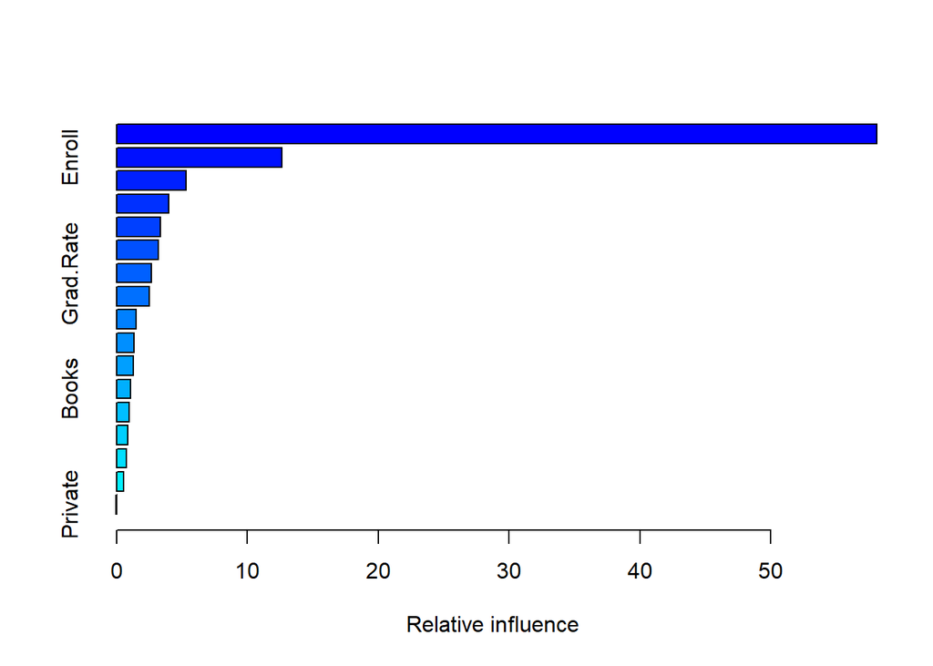

```
##                     var     rel.inf
## Accept           Accept 58.08963788
## Enroll           Enroll 12.65167808
## Top10perc     Top10perc  5.30389732
## Expend           Expend  3.97893742
## Outstate       Outstate  3.34785765
## F.Undergrad F.Undergrad  3.17666145
## Grad.Rate     Grad.Rate  2.64890460
## Top25perc     Top25perc  2.48755933
## perc.alumni perc.alumni  1.49807502
## Room.Board   Room.Board  1.30678366
## S.F.Ratio     S.F.Ratio  1.28719561
## Books             Books  1.05623682
## P.Undergrad P.Undergrad  0.97698730
## Personal       Personal  0.85828525
## Terminal       Terminal  0.73994494
## PhD                 PhD  0.56167285
## Private         Private  0.02968481
```

```r
#Final Model
gbm_3 <- gbm(formula = Apps ~ .,
             distribution = "gaussian",
             data = train,
             n.trees = 200,
             interaction.depth = 7,
             shrinkage = 0.2,
             n.minobsinnode = 3,
             bag.fraction = 0.3,
             train.fraction = 1,
             cv.folds = 0,
             n.cores = NULL, #will use all cores by default
)

summary(gbm_3)
```

```r
pred_gbm <- predict(gbm_3, n.trees = 200, newdata = test)
```

```r
abs_err_gbm <- abs(pred_gbm - test$Apps)
MSE_GBM<-mean((test$Apps-pred_gbm)^2)
rmse_gbm<-sqrt(mean((test$Apps-pred_gbm)^2))
```

MSE_GBM = 0.037711.

RMSE_gbm = 0.1941931.

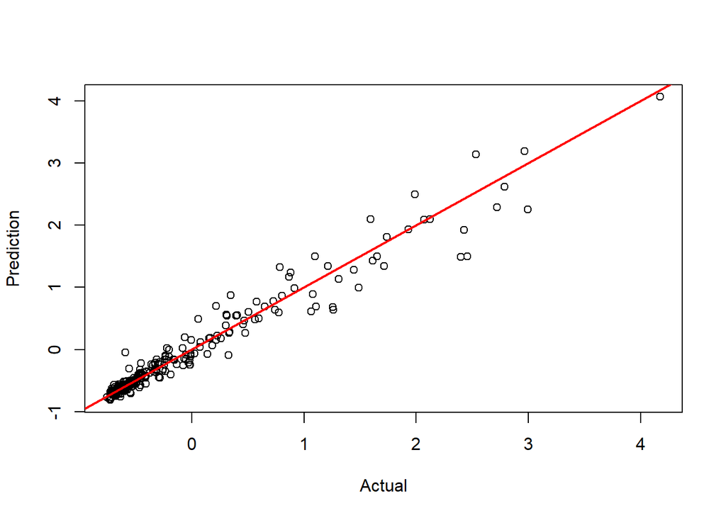

```r
#Actual vs. Predicted
plot(test$Apps, pred_gbm, xlab = "Actual", ylab = "Prediction")
abline(a = 0, b = 1, col = "red", lwd = 2)
```